# Lubridate

Jeff Parks

10/24/2021

# 1 Introduction

**Lubridate** is an R package that simplifies the handling of date and time data, one of the most common problems in data transformation.

[**Lubridate CheatSheet**](https://rawgit.com/rstudio/cheatsheets/master/lubridate.pdf)

## 1.1 Loading the package

While part of the **tidyverse**, Lubridate does not load by default using the **library(tidyverse)** command. Instead, load it separately:

```r
library(tidyverse)
library(lubridate)
```

## 1.2 Introducting date-times

A date-time is a data object representing a point on the timeline, typically to the nearest second, with notation as to the timezone represented.

For example, to get the current date use **today()**; for the current date-time, use **now()**:

```r
today() # returns a date only
```

```
## [1] "2021-11-26"
```

```r
now() # returns a date-time
```

```
## [1] "2021-11-26 13:57:34 EST"
```

# 2 Functions

For this exercise, we’ll use an excerpt of a Netflix dataset with date added per title.

```r
data <- ('https://raw.githubusercontent.com/jefedigital/cuny-data-607/main/data/netflix_titles.csv')

df <- read_csv(data) %>%
  select(title, date_added)
```

## 2.1 Parsing datetimes

Lubridate simplifies the parsing of strings and date-time objects and components into a uniform date-time format.

If we inspect the **date_added** field in the Netflix dataset, we notice these are character strings with long-form months spelled out. We’ll want to convert these into actual date-time objects.

```
## # A tibble: 5 x 2
##   title                 date_added
##   <chr>                 <chr>
## 1 Dick Johnson Is Dead  September 25, 2021
## 2 Blood & Water         September 24, 2021
## 3 Ganglands             September 24, 2021
## 4 Jailbirds New Orleans September 24, 2021
## 5 Kota Factory          September 24, 2021
```

To parse a given string to date-time, pass it to a function named for the order of the year (y), month (m), day (d), hour (h), minute (m) and second (s) elements in your data.

```r
mdy('September 1, 2020')
```

```
## [1] "2020-09-01"
```

We can use the **mdy** function to create a new column with **date_added** in date-time format:

```r
df <- df %>% mutate(date_added_dt = mdy(date_added))
```

```
## # A tibble: 5 x 3
##   title                 date_added         date_added_dt
##   <chr>                 <chr>              <date>
## 1 Dick Johnson Is Dead  September 25, 2021 2021-09-25
## 2 Blood & Water         September 24, 2021 2021-09-24
## 3 Ganglands             September 24, 2021 2021-09-24
## 4 Jailbirds New Orleans September 24, 2021 2021-09-24
## 5 Kota Factory          September 24, 2021 2021-09-24
```

## 2.2 Rounding Datetimes

Sometimes we want to round off date-time objects to the nearest unit of time (such as day, month or year.)

Lubridate provides three functions: **round_date** to round to the nearest unit, **floor_date** to round down, and **ceiling_date** to round up.

As an example, let’s round our new **date_added_dt** field down to the nearest month:

```r
df <- df %>%
  mutate(date_added_mon = floor_date(date_added_dt, unit='month'))
```

```
## # A tibble: 5 x 4
##   title                 date_added         date_added_dt date_added_mon
##   <chr>                 <chr>              <date>        <date>
## 1 Dick Johnson Is Dead  September 25, 2021 2021-09-25    2021-09-01
## 2 Blood & Water         September 24, 2021 2021-09-24    2021-09-01
## 3 Ganglands             September 24, 2021 2021-09-24    2021-09-01
## 4 Jailbirds New Orleans September 24, 2021 2021-09-24    2021-09-01
## 5 Kota Factory          September 24, 2021 2021-09-24    2021-09-01
```

## 2.3 Day of the Week/Month/Year

Lubridate can tell us where a day falls in the week, month and year with the **wday()**, **mday()** and **yday()** functions.

We can use this to answer the question are their patterns to when Netflix adds movies?

We are going to use these functions in addition to ggplot package to answer this question.

```r
#First convert all the dates to an unambiguous mdy format
df$date_added <- mdy(df$date_added)

#Filter out any missing dates
df <- df %>% filter(!is.na(date_added))

#Use the wday, mday and yday functions to get the day of the week/month/year
df <-
  df %>% mutate(day_of_wk = wday(date_added),
                day_of_month = mday(date_added),
                day_of_year = yday(date_added))
```

Let’s look at what day of the week most Netflix movies are added.

When interpreting this histogram it’s worth noting that the first day of the week is Sunday.

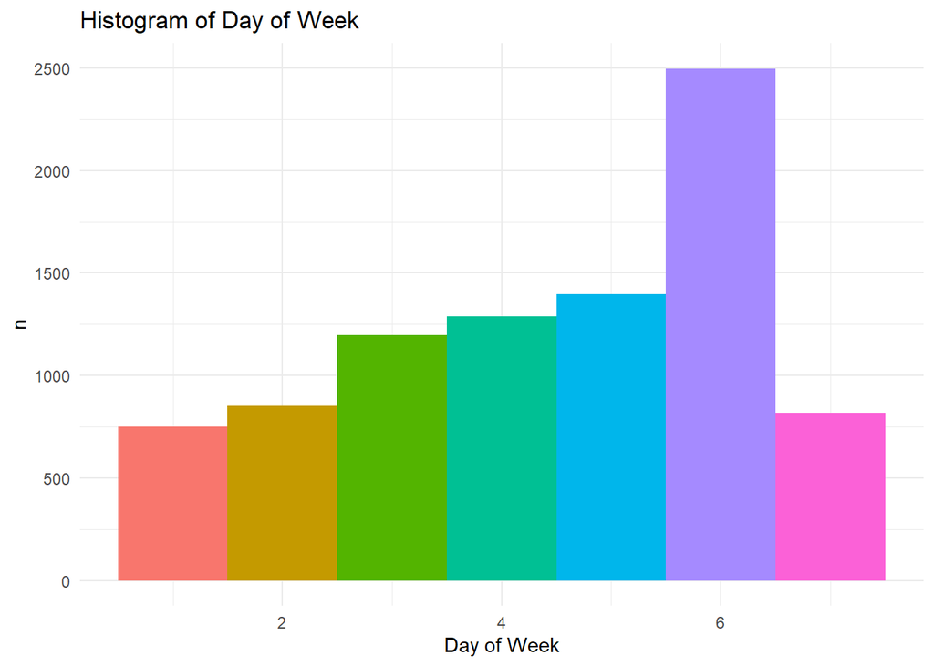

```r
# we are going to create histograms with a color gradient as we move across the week
ggplot(data = df, aes(x=day_of_wk, fill = cut(day_of_wk, 7))) +
  geom_histogram(show.legend = FALSE) +
  geom_histogram(show.legend = FALSE, bins=7) +
  theme_minimal() +
  labs(x = "Day of Week", y = "n") +
  ggtitle("Histogram of Day of Week")
```

We can see that most movies are added on a Friday.

Let’s look at what day of the month most Netflix movies are added.

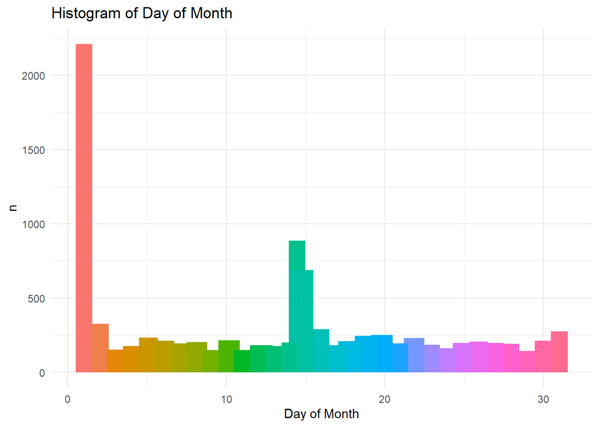

```r
# we are going to create histograms with a color gradient as we move across the month
ggplot(data = df, aes(x=day_of_month, fill = cut(day_of_month, 31))) +
  geom_histogram(show.legend = FALSE) +
  geom_histogram(show.legend = FALSE, bins=31) +
  theme_minimal() +
  labs(x = "Day of Month", y = "n") +
  ggtitle("Histogram of Day of Month")
```

We can see that most movies are added on the first day of the month.

Based on the last two histograms we already have some expectations, but let’s look at what day of the year most Nexflix movies are added.

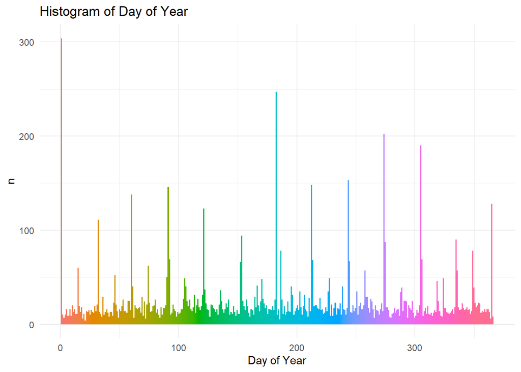

```r
# we are going to create histograms with a color gradient as we move across the year
ggplot(data = df, aes(x = day_of_year, fill = cut(day_of_year, 365))) +
  geom_histogram(show.legend = FALSE, bins=365) +
  theme_minimal() +
  labs(x = "Day of Year", y = "n") +
  ggtitle("Histogram of Day of Year")
```

We might expect to see 12 equidistant peaks but we see 13. It looks like while Netflix does add most movies on the first of the month, it also adds movies halfway through the month and on the last day of the year. All of this analysis was easily done with the **wday()**, **mday()**, **yday()** functions and the **ggplot()** function.